# Intro-Rmarkdown

1.Rainfall is typically measured in units of length. Cross reference an external source to find out what units this data set is in. Cite your source with a hyperlink, as described in the web page (Links to an external site.).

- The units are in inches: [precip data set information](https://stat.ethz.ch/R-manual/R-patched/library/datasets/html/precip.html)

2.Verify Sacramento is in the data.

```r
# names(precip)[6]
"Sacramento" %in% names(precip)
```

```
## [1] TRUE
```

3.Which 5 cities receive the most rain? The least rain?

- Mobile, Miani, San Juan, New Orleans and Juneau have the most rain.
- Boise, Albuquerque, El Paso, Reno and Phoenix have the least rain.

```r
data = sort(precip, decreasing = TRUE)
print(head(names(data), n=5))
```

```
## [1] "Mobile"      "Miami"       "San Juan"    "New Orleans" "Juneau"
```

```r
print(tail(names(data), n=5))
```

```
## [1] "Boise"       "Albuquerque" "El Paso"     "Reno"        "Phoenix"
```

4.How many times larger is the rainfall in the rainiest city compared to the least rainy city?

- Mobile has 9.57 times as much rainfall as Phoenix.

```r
first = data[1]
last = tail(data, n=1)
first[1]/last[1]
```

```
##   Mobile
## 9.571429
```

5.Which city is closest to the mean rainfall? The farthest from the mean rainfall?

- The closest is the value which has smallest distance from the mean. Clevelend is closest to the mean.

```r
mean = mean(precip)
which.min(abs(precip - mean(precip)))
```

```
## Cleveland
##        47
```

```r
sort(abs(precip-mean))[1]
```

```
## Cleveland
## 0.1142857
```

```r
mean = mean(precip)
first-mean
```

```
##   Mobile
## 32.11429
```

```r
mean-last
```

```
##  Phoenix
## 27.88571
```

6.Plot a histogram of precipitation. Interpret this histogram in one or two sentences. Most cities have average annual rainfall between 30-50 inches.

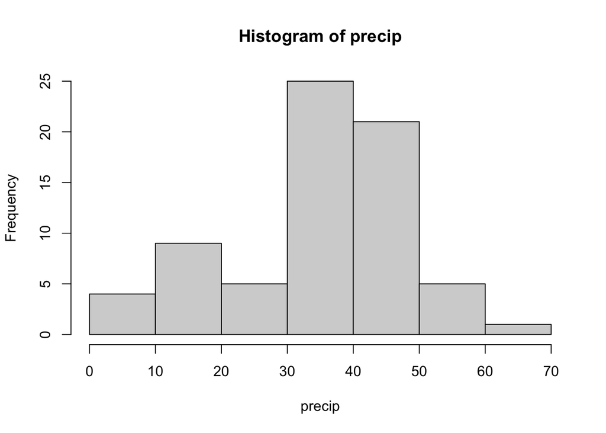

```r
hist(precip)
```

- The missing data to create this plot is latitude and longitude of each city.

- It rains more in the south and the northeast.